# Practical Machine Learning - Course Project

## Summary

Six participants were asked to perform Unilateral Dumbbell Biceps Curl in five different manners (Class A, B, C, D, E). Class A corresponds to the correct execution of the exercise while the other 4 classes are incorrect executions. Data was collected using accelerometers attached to the participants and dumbbells. More information is available from http://groupware.les.inf.puc-rio.br/har (see the section on the Weight Lifting Exercise Dataset).

The objective of the project is to predict the manner which the participants performed the exericse.

- Some exploratory data analysis is performed to understand the dataset.
- The data is santized to handle irrelevant attributes and missing values.
- Random Forest is selected to build the predictor.
- The predictor is evaluated to be highly accurate on both in-sample and out-of-sample observations.
- The predictor is applied onto the test dataset.

## Exploratory Data Analysis

- Empty strings and “NA” values are treated as null values.
- Some columns are highly sparse, having many null values. These columns are redundant and should be removed.
- The first 7 columns are deemed irrelevant. They should be excluded in the model.
- Missing values are present in the original datasets.
- The outcome variable takes on 5 values (A, B, C, D, E).
  - The percentage of ‘A’ is higher than the rest.

```r
# Read datasets
data.train <- read.csv("pml-training.csv", na.strings=c("", "NA"))
data.test <- read.csv("pml-testing.csv", na.strings=c("", "NA"))

# Display structure
str(data.train, list.len=30)
```

```
## 'data.frame':    19622 obs. of  160 variables:
##  $ X                       : int  1 2 3 4 5 6 7 8 9 10 ...
##  $ user_name               : Factor w/ 6 levels "adelmo","carlitos",..: 2 2 2 2 2 2 2 2 2 2 ...
##  $ raw_timestamp_part_1    : int  1323084231 1323084231 1323084231 1323084232 1323084232 1323084232 1323084232 1323084232 1323084232 1323084232 ...
##  $ raw_timestamp_part_2    : int  788290 808298 820366 120339 196328 304277 368296 440390 484323 484434 ...
##  $ cvtd_timestamp          : Factor w/ 20 levels "02/12/2011 13:32",..: 9 9 9 9 9 9 9 9 9 9 ...
##  $ new_window              : Factor w/ 2 levels "no","yes": 1 1 1 1 1 1 1 1 1 1 ...
##  $ num_window              : int  11 11 11 12 12 12 12 12 12 12 ...
##  $ roll_belt               : num  1.41 1.41 1.42 1.48 1.48 1.45 1.42 1.42 1.43 1.45 ...
##  $ pitch_belt              : num  8.07 8.07 8.07 8.05 8.07 8.06 8.09 8.13 8.16 8.17 ...
##  $ yaw_belt                : num  -94.4 -94.4 -94.4 -94.4 -94.4 -94.4 -94.4 -94.4 -94.4 -94.4 ...
##  $ total_accel_belt        : int  3 3 3 3 3 3 3 3 3 3 ...
##  $ kurtosis_roll_belt      : Factor w/ 396 levels "-0.016850","-0.021024",..: NA NA NA NA NA NA NA NA NA NA ...
##  $ kurtosis_picth_belt     : Factor w/ 316 levels "-0.021887","-0.060755",..: NA NA NA NA NA NA NA NA NA NA ...
##  $ kurtosis_yaw_belt       : Factor w/ 1 level "#DIV/0!": NA NA NA NA NA NA NA NA NA NA ...
```

[output cut: 17 more lines]

```r
# Display dimensions
dim(data.train)
```

```
## [1] 19622   160
```

```r
dim(data.test)
```

```
## [1]  20 160
```

```r
# View complete cases
sum(complete.cases(data.train))
```

```
## [1] 406
```

```r
sum(complete.cases(data.test))
```

```
## [1] 0
```

```r
# Preview outcome variable
summary(data.train$classe)
```

```
##    A    B    C    D    E
## 5580 3797 3422 3216 3607
```

## Data Preprocessing

- Sparse attributes (>= 90% null values) are dropped from the datasets. They provide minimal or no information.
- The remaining attributes do not have low variance.
- The dropped columns (from training dataset) are removed from the test dataset.
- The datasets are reduced from 160 attributes to 60 attributes (including first 7 supporting attributes).
- No missing values are present for the processed datasets.

```r
# Import packages
library(caret)
```

```r
library(ggplot2)
library(randomForest)
# Drop columns having 90% null/empty values
data.train.trim <- data.train[,colSums(!is.na(data.train)) >= 0.9 * nrow(data.train)]

# Drop numeric columns with near zero variance if any
columns.nzv <- nearZeroVar(data.train.trim[,sapply(data.train.trim, is.numeric)])
columns.nzv
```

```
## integer(0)
```

```r
if(length(columns.nzv) != 0)
  data.train.trim <- data.train.trim[,-columns.nzv]

# Drop same columns for test dataset
data.test.trim <- data.test[,-which(!(names(data.train) %in% names(data.train.trim)))]

# Display dimensions
dim(data.train.trim)
```

```
## [1] 19622    60
```

```r
dim(data.test.trim)
```

```
## [1] 20 60
```

```r
# View complete cases
sum(complete.cases(data.train.trim))
```

```
## [1] 19622
```

```r
sum(complete.cases(data.test.trim))
```

```
## [1] 20
```

## Model Fitting

- The original training dataset is split between partial-train (70%) and validation datasets (30%).
  - The partial train dataset is used for the model
- Random forests is used to build the model.
  - They are an ensemble learning method.
  - They construct a multitude of decision trees.
  - Features are randomly sampled (implicit feature selection).
- The first 7 attributes are excluded from the model.
- Repeated cross validation (3 repeats) is applied. Each iteration is 10-folds.
  - The model is stored and can be loaded to save time.
- The top 30 important variables are listed.

```r
# Create new training and validation datasets
rows.part <- createDataPartition(y=data.train.trim$classe, p=0.7, list=FALSE)

data.split.train <- data.train.trim[rows.part,]
data.split.validate <- data.train.trim[-rows.part,]

# Display dimensions
dim(data.split.train)
```

```
## [1] 13737    60
```

```r
dim(data.split.validate)
```

```
## [1] 5885   60
```

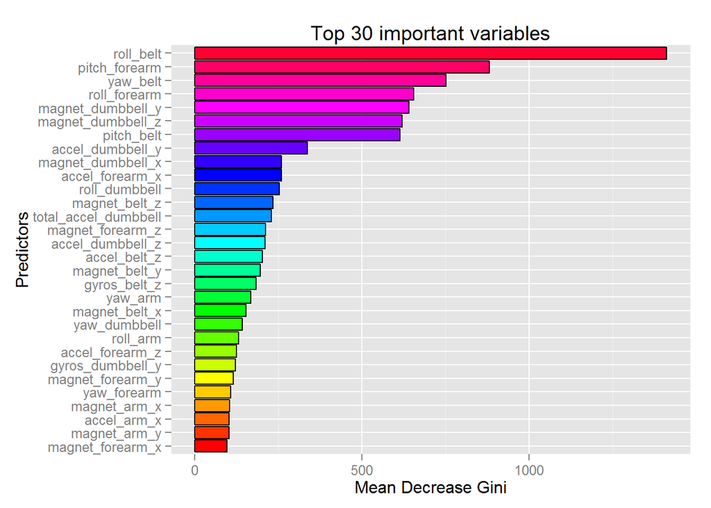

```r
# Initialize seed
set.seed(1342)

# Build model
#modelfit <- train(classe~., method="rf", data=data.split.train[,-c(1:7)], trace = TRUE,
#                   trControl=trainControl(method="repeatedcv", number=10, repeats=3))

# Save model
#saveRDS(modelfit, file = "rf-k10-r3.rds")

# Load model
modelfit <- readRDS(file = "rf-k10-r3.rds")

# View variable importance
#varImpPlot(modelfit$finalModel, sort=TRUE, n.var=20)

vars.top <- 30
vars.imp <- as.data.frame(modelfit$finalModel$importance)
vars.imp <- cbind(Variable=row.names(vars.imp), vars.imp)
vars.imp <- vars.imp[order(-vars.imp[,2]),]
vars.imp$Variable <- reorder(vars.imp$Variable, vars.imp$MeanDecreaseGini)

ggplot(vars.imp[1:vars.top,], aes(x=Variable, y=MeanDecreaseGini)) +
  geom_bar(stat="identity", fill=rainbow(vars.top), color="black") +
  labs(x="Predictors", y="Mean Decrease Gini", title=paste("Top", vars.top, "important variables")) +
  coord_flip()
```

## Model Evaluation

```r
# View Model
print (modelfit)
```

```
## Random Forest
##
## 13737 samples
##    52 predictor
##     5 classes: 'A', 'B', 'C', 'D', 'E'
##
## No pre-processing
## Resampling: Cross-Validated (10 fold, repeated 3 times)
##
## Summary of sample sizes: 12364, 12363, 12364, 12363, 12364, 12363, ...
##
## Resampling results across tuning parameters:
##
##   mtry  Accuracy   Kappa      Accuracy SD  Kappa SD
##    2    0.9917015  0.9895017  0.001944615  0.002460414
##   27    0.9919683  0.9898396  0.001592948  0.002015469
##   52    0.9829411  0.9784171  0.003586852  0.004539333
##
## Accuracy was used to select the optimal model using  the largest value.
## The final value used for the model was mtry = 27.
```

```r
# Predict validation dataset
predict.validate <- predict(modelfit, data.split.validate)

# View prediction results
confusionMatrix(predict.validate, data.split.validate$classe)
```

```
## Confusion Matrix and Statistics
##
##           Reference
## Prediction    A    B    C    D    E
##          A 1672    3    0    0    0
##          B    2 1135    0    0    0
##          C    0    1 1025    4    1
##          D    0    0    1  960    0
##          E    0    0    0    0 1081
##
## Overall Statistics
##
##                Accuracy : 0.998
##                  95% CI : (0.9964, 0.9989)
##     No Information Rate : 0.2845
##     P-Value [Acc > NIR] : < 2.2e-16
##
##                   Kappa : 0.9974
##  Mcnemar's Test P-Value : NA
##
## Statistics by Class:
##
##                      Class: A Class: B Class: C Class: D Class: E
## Sensitivity            0.9988   0.9965   0.9990   0.9959   0.9991
## Specificity            0.9993   0.9996   0.9988   0.9998   1.0000
## Pos Pred Value         0.9982   0.9982   0.9942   0.9990   1.0000
## Neg Pred Value         0.9995   0.9992   0.9998   0.9992   0.9998
## Prevalence             0.2845   0.1935   0.1743   0.1638   0.1839
## Detection Rate         0.2841   0.1929   0.1742   0.1631   0.1837
## Detection Prevalence   0.2846   0.1932   0.1752   0.1633   0.1837
## Balanced Accuracy      0.9990   0.9980   0.9989   0.9978   0.9995
```

## Model Prediction

- The model is applied on the test dataset.
- Each observation is written in a text file.
  - The problem id is used as the filename.

```r
# Predict test dataset
predict.test <- predict(modelfit, data.test.trim)

# Write predictions to file
for (i in 1:length(predict.test))
{
  filename = paste0("problem_id_", i, ".txt")
  write.table(predict.test[i], file=filename, quote=FALSE, row.names=FALSE, col.names=FALSE)

  print(paste0("Problem Id [", i, "] - Predicted Class: ", predict.test[i]))
}# end for
```

```
## [1] "Problem Id [1] - Predicted Class: B"
## [1] "Problem Id [2] - Predicted Class: A"
## [1] "Problem Id [3] - Predicted Class: B"
## [1] "Problem Id [4] - Predicted Class: A"
## [1] "Problem Id [5] - Predicted Class: A"
## [1] "Problem Id [6] - Predicted Class: E"
## [1] "Problem Id [7] - Predicted Class: D"
## [1] "Problem Id [8] - Predicted Class: B"
## [1] "Problem Id [9] - Predicted Class: A"
## [1] "Problem Id [10] - Predicted Class: A"
## [1] "Problem Id [11] - Predicted Class: B"
## [1] "Problem Id [12] - Predicted Class: C"
## [1] "Problem Id [13] - Predicted Class: B"
## [1] "Problem Id [14] - Predicted Class: A"
## [1] "Problem Id [15] - Predicted Class: E"
## [1] "Problem Id [16] - Predicted Class: E"
## [1] "Problem Id [17] - Predicted Class: A"
## [1] "Problem Id [18] - Predicted Class: B"
## [1] "Problem Id [19] - Predicted Class: B"
## [1] "Problem Id [20] - Predicted Class: B"
```